# SwiftKey Project_ Milestone Report

### 3. Trigram

#### a. Frequency Table

```r
tri.freq = getFreq(corpus,3)

kable(tri.freq[1:top,],row.names = F) %>%
  kable_styling(bootstrap_options="striped",full_width=F)%>%
  scroll_box(width = "100%", height = "400px")
```

| word | freq |
| --- | --- |
| new york times | 5 |
| president barack obama | 5 |
| digs service points | 4 |
| let us get | 4 |
| nice hair guy | 4 |
| age grade range | 3 |
| aug age grade | 3 |
| can wait see | 3 |
| chicago chicago illinois | 3 |
| cloths cold water | 3 |
| five times week | 3 |
| four years ago | 3 |
| gov chris christie | 3 |
| grade range yo | 3 |
| happy mother day | 3 |
| happy mothers day | 3 |
| hope great day | 3 |
| let us make | 3 |
| like year old | 3 |
| new york state | 3 |

#### b. Frequency Histogram

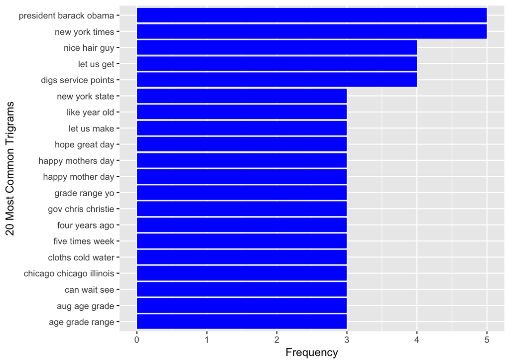

```r
makePlot(tri.freq[1:top,], "20 Most Common Trigrams")
```

#### c. Frequency Wordcloud

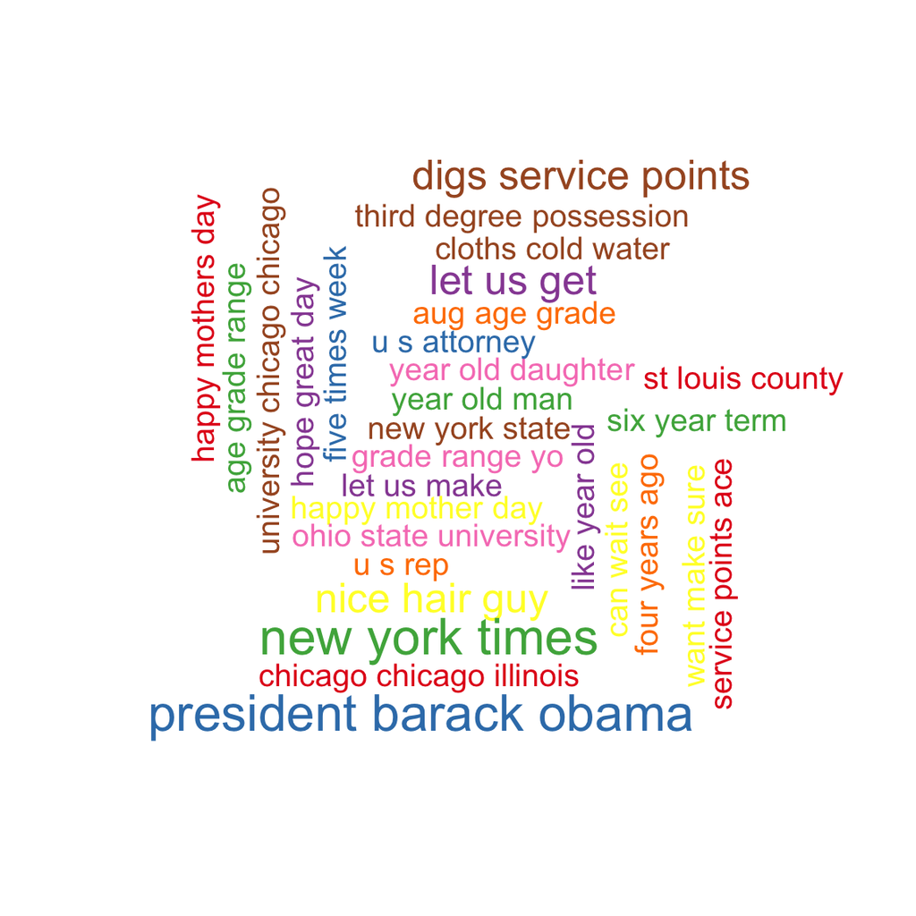

```r
wordcloud(words = tri.freq$word, freq = tri.freq$freq, min.freq = 1,
            max.words=30, random.order=T, rot.per=0.35, random.color = T,scale=c(2,.1),
            colors=brewer.pal(8,name= "Set1"))
```

## Findings

We can conclude after the exploratory analysis that the process is very heavy and requires a lot of processing power and RAM. A lot of the frequent words are repeated. The more complex the N-Gram the lower the frequency

## What Next?

Prediction model and plans for Shiny app While the strategy for modeling and prediction has not been finalized, the n-gram model with a frequency look-up table might be used based on the analysis above. A possible method of prediction is to use the 4-gram model to find the most likely next word first. If none is found, then the 3-gram model is used, and so forth. Furthermore, stemming might also be done in data preprocessing.

For the app a simple minimalistic design with probabibily of next word showing displayed, or a button to introduced the next word prediction.